[output not shown]

# Intro

It is unclear how individuals choose to search for information through the multimedia environment of the 21st century. Much of the research conducted in social networks and communication focus on senders, influencers, and persuasion strategies (Merton 1968) rather than on “the receiver as an active information seeker and processor.” (Johnson and Meischke 1993).

Core discussion networks are the default lens to investigate network resources and social support in surveys. The underlying assumption is that individuals reach out to a handful of strong ties when in need of support, which can be elicited in surveys using name generators (Marsden 1987). This approach has yielded important insights, but largely overlooks crucial processes of resource activation (Hurlbert, Haines, and Beggs 2000; Perry and Pescosolido 2015; Smith 2005). Small (2017) shows that the core discussion network does not capture how people activate social support in practice and indicates that people draw on much broader social connections for support, also calling back to the weak ties research by Granovetter (1973). There is ongoing research investigating how weak-tie support holds for different support types based on the architecture put forward by House, Umberson, and Landis (1988) of instrumental, emotional, and informational support (Legewie and Gonzalez 2020). I follow the definition of Cohen and Wills (1985) and define informational support as “help in defining, understanding, and coping with problematic events and include education, advice, or referral to another source of support” (Winemiller et al. 1993:640).

As online search or interaction also allows increased anonymity, no or lowered social cost, and the potential avoidance of embarrassment and other negative social interactions, I theorize that a majority of people who searched for information will have done so online.

For this paper, I will use the case of Covid-19 vaccinations to explore the variation among information search vehicles. There are theoretical reasons why individuals would choose to search for information among their network ties instead of online search. For instance, Rains (2018) finds that patients tend to search for technical information about an illness online but turn to their social network for experiential information from others facing similar circumstances in the case of cancer. Moreover, if an individual distrusts the medical establishment, or popular media, they may be more likely to activate informational support among their social network or turn to online groups that validate their worldview (Bogers and Wernersen 2014).

This research project is important because the vehicles used to search by people impacts the information they are exposed to. Given the large swaths of both misinformation and disinformation regarding Covid-19 (Motta, Stecula, and Farhart 2020; Pathak, Agarawalla, and Gupta 2020; Shahsavari et al. 2020) and the measurable impacts this misinformation has had on pandemic-related health behaviors, how we choose to search for information affects our own lives and the lives of others. Moreover, individuals who do not utilize social networks for information search may feel like they have no network support, leading to feelings of network isolation with major implications for mental health (Thoits 2011).

## section B: Research Questions

- How do computer-mediated or interpersonal network information-seeking strategies vary across populations?
- What factors lead people to perform health information search online versus among social network ties?
- How does the utilization of social networks, search engines, and social media as vary in the case of searching for information on the Covid-19 vaccine?

# Research Methodology

- grant sample
- MTurk
- Dates
- Locations

Descriptive Statistics

I received a $7,193 grant from the Summer Institute of Computational Social Science to conduct research on network activation. Because I am co-PI on this grant with my colleague Nicolas Legewie (University of Pennsylvania, Humboldt-University of Berlin), I established permissions early-on in our planning process to introduce and ‘own’ a few specific survey questions for independent research on network versus non-network information activation.

The majority of this survey is a replication of the survey conducted in Mario Small’s Book, Someone to Talk To (2017). We aim to expand on Small’s finding that people draw on much broader sources than “important people” for support by investigating how this theory of weak-tie support holds for different support types (instrumental, emotional, and informational support; (see House et al. 1988)).

We aim to conduct surveys with 900 participants. The sample population for our main survey are adult, non-institutionalized US residents. To adjust for the non-representative sample provided by Amazon Mechanical Turk where we will host the survey, we will use post-stratification weights based on the demographic profile of each respondent (Wang et al. 2015).

Descriptive Statistics for Dichotomous and Numeric Variables

[output not shown]

Notes: 949 Surveyed, Conducted December 03 through December 12, 2021.

Descriptive Statistics for Categorical Variables

[output not shown]

Notes: 949 Surveyed, Conducted December 03 through December 12, 2021.

# What predicts someone intentionally searched for information

Q171 And how about you yourself intentionally looking for information about a Covid-19 vaccine? Such information can include things such as advice, clarification, facts, and experiences.

- Yes
- No

What predicts someone intentionally searched for information

|  | Model 1 |
| --- | --- |
| Received Info, Doctor | 2.831*** |
|  | (0.180) |
| Received Info, Person | 1.938*** |
|  | (0.170) |
| Received Info, News | 1.366+ |
|  | (0.175) |
| Received Info, Social Networking Site | 1.257 |
|  | (0.184) |
| Received Info, Online Forum | 2.443*** |
|  | (0.203) |
| Age | 0.977** |
|  | (0.009) |
| Some College + | 2.009* |
|  | (0.282) |
| White | 2.140 |
|  | (0.586) |
| Black | 3.234+ |
|  | (0.638) |
| Native American | 1.696 |
|  | (0.731) |
| Asian | 0.973 |
|  | (0.588) |
| Num.Obs. | 948 |
| BIC | 984.7 |
| Log.Lik. | -444.382 |
| F | 6.541 |

Exponentiated Coefficients

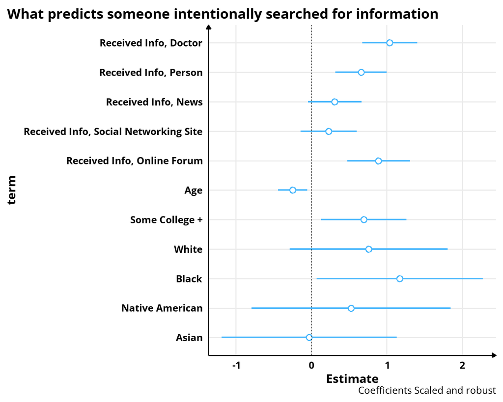

Plot of Coefficients, Model 1

# What is associated with using different kinds of search vehicles?

Q172 How did you look for information about the Covid-19 vaccine?

- Asking a person like friend, neighbor, or family member that I know
- Asking my doctor or another health professional
- Posted queries in an online discussion group, listserve, or other online forum like a Facebook Group or Subreddit
- Posted queries on a social networking site such as Facebook timeline, Twitter status update, or Linkedin
- Searched for my question using an online search engine such as Google or Bing
- Other ________________________________________________

What predicts someone intentionally searched for information, by vehicle of information search

|  | Person | Doctor | Online Forum | Social Networking Site | Online Search |
| --- | --- | --- | --- | --- | --- |
| Received Info, Doctor | 3.150*** | 7.049*** | 1.310+ | 1.924*** | 1.340+ |
|  | (0.147) | (0.154) | (0.160) | (0.183) | (0.154) |
| Received Info, Person | 3.381*** | 2.287*** | 2.224*** | 1.457+ | 1.297 |
|  | (0.164) | (0.169) | (0.185) | (0.214) | (0.165) |
| Received Info, News | 1.093 | 1.540* | 1.369+ | 1.604* | 2.952*** |
|  | (0.160) | (0.168) | (0.179) | (0.217) | (0.172) |
| Received Info, Social Networking Site | 1.502** | 0.806 | 0.472*** | 1.660** | 3.975*** |
|  | (0.157) | (0.170) | (0.183) | (0.193) | (0.158) |
| Received Info, Online Forum | 1.310+ | 1.576** | 3.614*** | 2.776*** | 1.834*** |
|  | (0.160) | (0.170) | (0.171) | (0.189) | (0.165) |
| Age | 1.000 | 1.000 | 1.010 | 1.006 | 0.969*** |
|  | (0.007) | (0.007) | (0.008) | (0.009) | (0.007) |
| Some College + | 0.972 | 2.327** | 2.447* | 1.772 | 0.733 |
|  | (0.277) | (0.323) | (0.372) | (0.404) | (0.281) |
| White | 1.246 | 1.725 | 0.913 | 1.506 | 1.148 |
|  | (0.381) | (0.410) | (0.451) | (0.424) | (0.404) |
| Black | 1.218 | 1.301 | 1.590 | 1.589 | 1.554 |
|  | (0.398) | (0.428) | (0.454) | (0.439) | (0.421) |
| Native American | 0.516 | 1.376 | 1.440 | 2.305+ | 0.405+ |
|  | (0.475) | (0.504) | (0.513) | (0.485) | (0.516) |
| Asian | 0.549 | 0.677 | 0.080** | 0.500 | 2.210+ |
|  | (0.440) | (0.465) | (0.786) | (0.567) | (0.449) |
| Num.Obs. | 948 | 948 | 948 | 948 | 948 |
| BIC | 1232.0 | 1150.5 | 1070.8 | 894.4 | 1136.1 |
| Log.Lik. | -568.012 | -527.255 | -487.407 | -399.215 | -520.059 |
| F | 9.840 | 14.659 | 7.831 | 6.927 | 14.192 |

Note: Exponentiated Coefficients

# Researching how you search for vaccination information affects vaccination status

Does receiving or searching for information predict vaccination status?

|  | Model 1 |
| --- | --- |
| Received Info, Doctor | 2.981*** |
|  | (0.293) |
| Received Info, Person | 0.909 |
|  | (0.234) |
| Received Info, News | 1.066 |
|  | (0.242) |
| Received Info, Social Networking Site | 0.395*** |
|  | (0.234) |
| Received Info, Online Forum | 0.735 |
|  | (0.241) |
| Sought Info, Doctor | 4.209*** |
|  | (0.334) |
| Sought Info, Person | 1.775* |
|  | (0.279) |
| Sought Info, Social Networking Site | 2.602* |
|  | (0.454) |
| Sought Info, Online Forum | 1.681 |
|  | (0.332) |
| Sought Info, Online Search | 0.877 |
|  | (0.249) |
| Age | 1.022* |
|  | (0.010) |
| Some College + | 3.101*** |
|  | (0.310) |
| White | 2.379 |
|  | (0.792) |
| Black | 1.633 |
|  | (0.822) |
| Native American | 1.478 |
|  | (0.881) |
| Asian | 3.471 |
|  | (0.895) |
| Num.Obs. | 936 |
| BIC | 688.4 |
| Log.Lik. | -279.214 |
| F | 5.851 |

Note: Exponentiated Coefficients

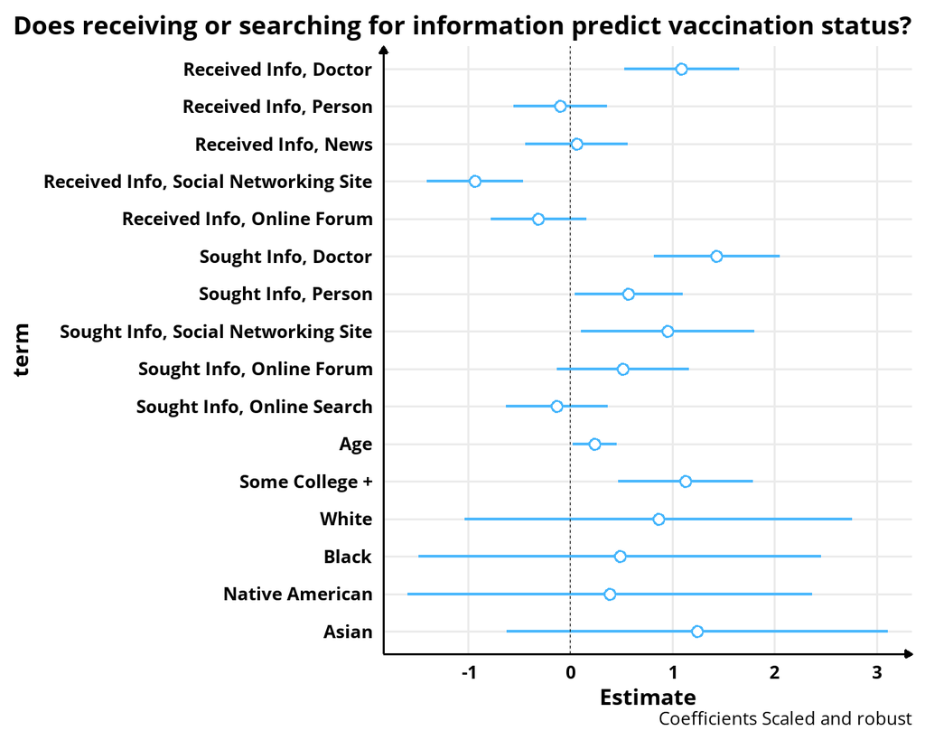

# Appendix 1: Survey Questions

*Q181*: Now, we’re going to transition a bit to ask you about the information you received during the Covid-19 pandemic.

*Q170*: In the past 12 months, without searching for it, did you receive information about the Covid-19 vaccine from … (check all sources you received information from)

- your doctor or other health professional? (1)
- a person like friend, neighbor, or family member that you know ? (9)
- From television news channel or the newspaper? (10)
- From an online discussion group, listserve, or other online forum including a Facebook group or subreddit? (11)
- From a social networking site such as Facebook timeline, Twitter status update, or linkedin? (12)
- Other (13) ________________________________________________

*Q171*: And how about you yourself intentionally looking for information about a Covid-19 vaccine? Such information can include things such as advice, clarification, facts, and experiences.

- Yes (4)
- No (5)

*Q172*: How did you look for information about the Covid-19 vaccine?

- Asking a person like friend, neighbor, or family member that I know (1)
- Asking my doctor or another health professional (4)
- Posted queries in an online discussion group, listserve, or other online forum like a Facebook Group or Subreddit (5)
- Posted queries on a social networking site such as Facebook timeline, Twitter status update, or Linkedin (6)
- Searched for my question using an online search engine such as Google or Bing (7)
- Other (8) ________________________________________________

*Q173*: What sort of information did you search for? Separate different topics with a comma or semi-colon. ___________

*Q174*: How useful was the information you found?

- Extremely useful (22)
- Very useful (23)
- Moderately useful (24)
- Slightly useful (25)
- Not at all useful (26)

*Q175*: Did the information you learned affect your decision to get vaccinated against Covid-19?

- Yes (39)
- No (40)

*Q179*: Did you receive a Covid-19 vaccine?

- Yes (9)
- No (10)
- I’m unsure or would not like to respond (11)

*Q180*: Do you plan to receive a vaccine for the prevention of the Covid-19 virus?

- Definitely not (9)
- Probably not (10)
- Might or might not (11)
- Probably yes (12)
- Definitely yes (13)
- I would not like to respond (14)

*gender*: What is your gender?

- Male (1)
- Female (2)
- Other (3) ________________________________________________
- Prefer not to say (4)

*hispanic*: Are you Hispanic, Latino/a/x, or Latin American Origin?

- Yes (1)
- No (2)

*race*: What is your race? If you are “mixed race,” select all that apply.

- White (1)
- Black or African American (2)
- American Indian or Alaskan Native (3)
- Asian (please specify): (4) ________________________________________________
- Other (please specify): (5) ________________________________________________
- Prefer not to say (6)

*educ*: What is the highest level of education that you have completed?

- Less than high school (1)
- High school graduate (2)
- Some college (3)
- Associate’s or Technical degree (4)
- Bachelor’s degree (5)
- Graduate or professional degree (6)

*income*: We would be interested to know roughly what your total household income before taxes is. We mean income from all sources, including welfare, stock dividends, other household members’ income, etc. In 2020, in which bracket did your total family income fall?

- Under $1,000 (1)
- $1,000 to $9,999 (2)
- $10,000 to $19,999 (3)
- $20,000 to $29,999 (4)
- $30,000 to $39,999 (5)
- $40,000 to $49,999 (6)
- $50,000 to $59,999 (7)
- $60,000 to $74,999 (8)
- $75,000 to $89,999 (9)
- $90,000 to $109,999 (10)
- $110,000 to $129,999 (11)
- $130,000 to $149,999 (12)
- $150,000 or over (13)
- Don’t know (14)

*age*: What is your age? (in years)